# Untitled

Foopaul

2023-05-21

# Tidyverse

```r
library(tidyverse)
```

# 0. Loading and preprocessing the data

## 0.1 Load the data

```r
activity <- read.csv("activity.csv")
```

## 0.2 Process/transform the data (if necessary)

```r
activity$date <- as_date(activity$date)

weekday <- weekdays(activity$date)

activity <-cbind(activity, weekday)

summary(activity)
```

```
##      steps             date               interval        weekday
##  Min.   :  0.00   Min.   :2012-10-01   Min.   :   0.0   Length:17568
##  1st Qu.:  0.00   1st Qu.:2012-10-16   1st Qu.: 588.8   Class :character
##  Median :  0.00   Median :2012-10-31   Median :1177.5   Mode  :character
##  Mean   : 37.38   Mean   :2012-10-31   Mean   :1177.5
##  3rd Qu.: 12.00   3rd Qu.:2012-11-15   3rd Qu.:1766.2
##  Max.   :806.00   Max.   :2012-11-30   Max.   :2355.0
##  NA's   :2304
```

# 1. What is mean total number of steps taken per day?

## 1.1 Make a histogram of the total number of steps taken each day

```r
activity.tsteps<- with(activity,
                       aggregate(steps, by = list(date),
                                 FUN = sum, na.rm = TRUE))

names(activity.tsteps)<- c("dates", "steps")
```

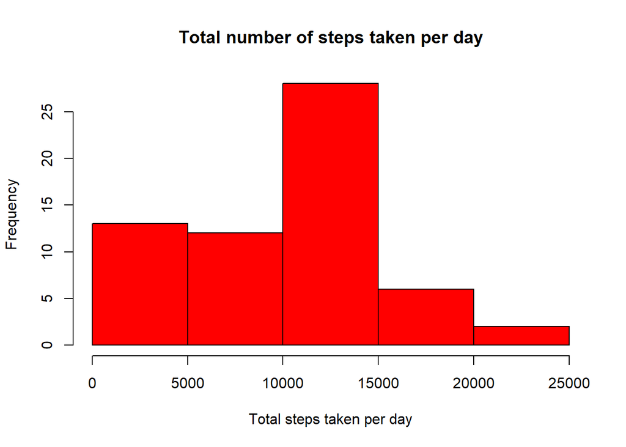

```r
hist(activity.tsteps$steps,
     main = "Total number of steps taken per day",
     xlab = "Total steps taken per day",
     col = "red")
```

## 1.2 Calculate and report the mean and median of the total number of steps taken per day

```r
mean(activity.tsteps$steps)
```

```
## [1] 9354.23
```

```r
median(activity.tsteps$steps)
```

```
## [1] 10395
```

# 2. What is the average daily activity pattern?

## 2.1 Make a time series plot of the 5-minute interval (x-axis) and the average number of steps taken, averaged across all days (y-axis)

```r
average.daily.activity <- aggregate(activity$steps,
                                   by= list(activity$interval),
                                   FUN = mean , na.rm = TRUE)

names(average.daily.activity) <- c("interval", "mean")
```

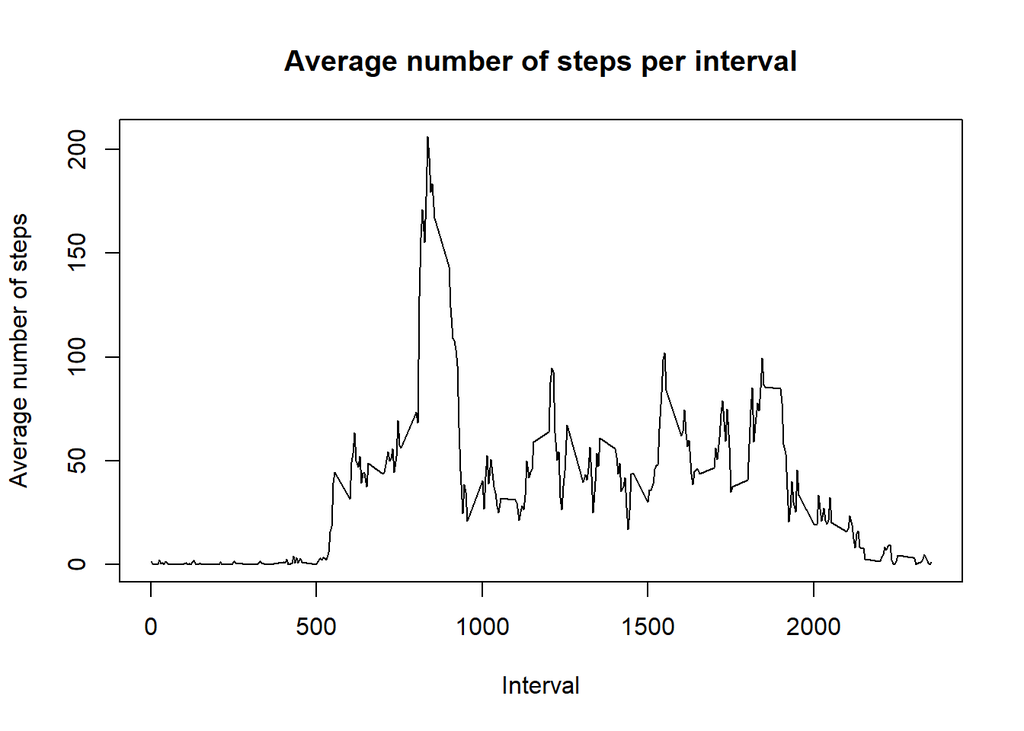

```r
plot(average.daily.activity$interval, average.daily.activity$mean,
     type = "l", xlab = "Interval",
     ylab = "Average number of steps",
     main = "Average number of steps per interval")
```

## 2.2 Which 5-minute interval, on average across all the days in the dataset, contains the maximum number of steps?

```r
average.daily.activity[which.max(average.daily.activity$mean),]$interval
```

```
## [1] 835
```